# Sentiments Expressed in Hotel Reviews

Reeve Paul

## Importing Libraries

```r
library(ggplot2)
library(tidytext)
library(syuzhet)
library(dplyr)
library(tibble)
library(reshape2)
```

```r
# Read CSV files from the raw file URLs
hotel1 <- read.csv("C:\\Users\\reeve\\OneDrive\\Desktop\\DSC-570\\Hotel-Sentiment-Analysis\\hotel1.csv")
hotel2 <- read.csv("C:\\Users\\reeve\\OneDrive\\Desktop\\DSC-570\\Hotel-Sentiment-Analysis\\hotel2.csv")
hotel3 <- read.csv("C:\\Users\\reeve\\OneDrive\\Desktop\\DSC-570\\Hotel-Sentiment-Analysis\\hotel3.csv")
```

## Exploring and Cleaning the Data

```r
head(hotel1)
```

```
##                Hotel
## 1 40 Berkeley Hostel
## 2 40 Berkeley Hostel
## 3 40 Berkeley Hostel
## 4 40 Berkeley Hostel
## 5 40 Berkeley Hostel
## 6 40 Berkeley Hostel
##                                                                                                                                                                                                                                                                                                          …
## 1                  We booked this hostel because it was the cheapest place in the Center area in boston. When we got there there was a mixup with our reservation and they took care of it right away. Excellent customer service at the front desk, very polite and helpful, answered all our questions.…
## 2                                                Good place to stay for a few days. Clean rooms, helping staff and clean bathrooms. The common area is nice and fun with a pool table and a small cinema room. Its the best you can get in Boston for this price. Good place as well. Might not fit a fam…
## 3                                                                                                                                                                                                                                                                                                        …
## 4 The location is perfect for getting to all of the sections and access to subway stops. Easy to figure out and navigate from Berkley location. One must assume that you won't have all the luxury amenities as the Courtyard Marriott. Taking this into consideration my negative points were was the qu…
## 5                            I was traveling for work and there was an issue at our hotel so I scrambled for an alternative solution and found 40 Berkeley. The lobby was clean and comfortable and the staff was friendly. I liked that bed linens and towels were included in the room price so I didn'…
## 6                                              We arrived to Boston on Amtrak late (11pm) and hustled a car to the hostel. We were quickly checked in and put in a larger room as the 2 bed unit we reserved was unavailable. The room was sparse but provided the beds we needed and a mini fridge as a …
```

```r
head(hotel2)
```

```
##                            Hotel
## 1 A Bed & Breakfast In Cambridge
## 2 A Bed & Breakfast In Cambridge
## 3 A Bed & Breakfast In Cambridge
## 4 A Bed & Breakfast In Cambridge
## 5 A Bed & Breakfast In Cambridge
## 6 A Bed & Breakfast In Cambridge
##                                                                                                                                                                                                                                                                                                          …
## 1                                              Breakfast was the best, and the best thing about the stay was the one and only host, great conversations at breakfast and advise on the city. Very nice neighborhood. Only reason that it did not get 5 stars is that the room has room for improvement, n…
## 2 A nice BB really close to Harvard Square. A little confusing getting there if your walking (very little to no street signs) but ultimately a call to the BB saved me from wondering around. Quiet neighborhood, bed was comfortable and bathroom was good considering that this is a very old building …
## 3                                                                                                                                                                                                                                                                                                        …
## 4                                                                                                                                                                                                                                                                                                        …
## 5                                                                                                                                                                                                                                                                                                        …
## 6                                                                                                                                                                                                                                                                                                        …
```

```r
head(hotel3)
```

```
##                        Hotel
## 1 Ambassadors Inn and Suites
## 2 Ambassadors Inn and Suites
## 3 Ambassadors Inn and Suites
## 4 Ambassadors Inn and Suites
## 5 Ambassadors Inn and Suites
## 6 Ambassadors Inn and Suites
##                                                                                                                                                                                                                                                                                                          …
## 1                                                                                                                                                                                                                                                                                                        …
## 2                                                                                                                                                                                                                                                                                                   Room …
## 3                                                                                                                                                                                                                             The hotel was great for our stay. It was a couples trip for beach week. The…
## 4                                                                                                                                                                                                                                                                                               Not a bad…
## 5                                                                                                                                                                                                                                                                                                        …
## 6 Went to Virginia Beach to pick up our son from deployment. Checked into our hotel on Friday evening. Went to our room, which looked nice at first. Looked under the mattress only to find a bedbug. Manager tried to say it was a cockroach. They did offer to upgrade our room but I just wanted a ref…
```

As can be seen above, the datasets for all the hotels contain two columns consisting of the hotel name and the respective review. In order to use the get_sentences() function, the dataframe should be manipulated to have one column for the review text, and one row per review. So, the second column will be extracted into a new dataframe for this purpose.

It is then possible to convert the reviews into sets of sentences using get_sentences(). An example of the sentences from the hotel 1 reviews can be seen below.

```r
# Convert review text into sets of sentences
sentences1 <- lapply(hotel1[,2], function(x) get_sentences(x))
sentences1 <- melt(sentences1)
sentences1 <- sentences1 %>% mutate(row_number = row_number())

colnames(sentences1) <- c("review","L1","id")



sentences2 <- lapply(hotel2[,2], function(x) get_sentences(x))
sentences2 <- melt(sentences2)
sentences2 <- sentences2 %>% mutate(row_number = row_number())

colnames(sentences2) <- c("review","L1","id")


sentences3 <- lapply(hotel3[,2], function(x) get_sentences(x))
sentences3 <- melt(sentences3)
sentences3 <- sentences3 %>% mutate(row_number = row_number())

colnames(sentences3) <- c("review","L1","id")


head(sentences1)
```

```
##                                                                                               review
## 1              We booked this hostel because it was the cheapest place in the Center area in boston.
## 2      When we got there there was a mixup with our reservation and they took care of it right away.
## 3 Excellent customer service at the front desk, very polite and helpful, answered all our questions.
## 4                                                    The room was a twin on the sixth floor, very...
## 5                                                                                               More
## 6                                                                 Good place to stay for a few days.
##   L1 id
## 1  1  1
## 2  1  2
## 3  1  3
## 4  1  4
## 5  1  5
## 6  2  6
```

## Sentiment model

The sentiment model below splits each review into words and assigns a numeric sentiment score to each word using the “AFINN” lexicon. The sentiment score for each word is added together to find the sentiment score of the review. Positive scores indicate positive sentiment, and negative scores indicate negative sentiment. Additionally, words that are not in the lexicon are excluded from the data frame.

```r
words1 <- sentences1 %>%
  unnest_tokens(word, review)

sentiments1 <- words1 %>%
  inner_join(get_sentiments("afinn"), by = "word")

review_sentiments1 <- sentiments1 %>%
  group_by(id) %>%
  summarise(sentiment = sum(value))

review_scores1 <- left_join(sentences1, review_sentiments1, by = "id")
review_scores1 = subset(review_scores1, select = -c(L1,id) )



words2 <- sentences2 %>%
  unnest_tokens(word, review)

sentiments2 <- words2 %>%
  inner_join(get_sentiments("afinn"), by = "word")

review_sentiments2 <- sentiments2 %>%
  group_by(id) %>%
  summarise(sentiment = sum(value))

review_scores2 <- left_join(sentences2, review_sentiments2, by = "id")
review_scores2 = subset(review_scores2, select = -c(L1,id) )



words3 <- sentences3 %>%
  unnest_tokens(word, review)

sentiments3 <- words3 %>%
  inner_join(get_sentiments("afinn"), by = "word")

review_sentiments3 <- sentiments3 %>%
  group_by(id) %>%
  summarise(sentiment = sum(value))

review_scores3 <- left_join(sentences3, review_sentiments3, by = "id")
review_scores3 = subset(review_scores3, select = -c(L1,id) )


head(review_scores1, 10)
```

```
##                                                                                                review
## 1               We booked this hostel because it was the cheapest place in the Center area in boston.
## 2       When we got there there was a mixup with our reservation and they took care of it right away.
## 3  Excellent customer service at the front desk, very polite and helpful, answered all our questions.
## 4                                                     The room was a twin on the sixth floor, very...
## 5                                                                                                More
## 6                                                                  Good place to stay for a few days.
## 7                                                     Clean rooms, helping staff and clean bathrooms.
## 8                          The common area is nice and fun with a pool table and a small cinema room.
## 9                                                  Its the best you can get in Boston for this price.
## 10                                                                                Good place as well.
##    sentiment
## 1         NA
## 2          2
## 3          5
## 4         NA
## 5         NA
## 6          3
## 7          6
## 8          7
## 9          3
## 10         3
```

```r
head(review_scores2, 10)
```

```
##                                                                                                                                               review
## 1      Breakfast was the best, and the best thing about the stay was the one and only host, great conversations at breakfast and advise on the city.
## 2                                                                                                                            Very nice neighborhood.
## 3                                      Only reason that it did not get 5 stars is that the room has room for improvement, not any fault of the host.
## 4                                                               This is bed and breakfast, but not your honeymoon style BB, I would stay here again.
## 5                                                           Room comfort could improve with a new air conditioning unit, other then that five stars.
## 6                                                      Sharing the bathroom, never a problem, and coming in and out with you wanted never a problem.
## 7                                                                                            No need to rent a car, easy with public transportation.
## 8                                                                                                          A nice BB really close to Harvard Square.
## 9  A little confusing getting there if your walking (very little to no street signs) but ultimately a call to the BB saved me from wondering around.
## 10                  Quiet neighborhood, bed was comfortable and bathroom was good considering that this is a very old building so keep that in mind.
##    sentiment
## 1          9
## 2          3
## 3          2
## 4         NA
## 5          4
## 6         -4
## 7          0
## 8          3
## 9         -1
## 10         5
```

```r
head(review_scores3, 10)
```

```
##                                                                review sentiment
## 1                                                           Relaxing.        NA
## 2                                                  Nice and peaceful.         5
## 3                                            Room could use upgrades.        NA
## 4                                It is not walking distance to beach.        NA
## 5    better to pay the extra to stay closer to beach and restaurants.         1
## 6                                   The hotel was great for our stay.         3
## 7                               It was a couples trip for beach week.        NA
## 8  The only things I didn't like was the cleanliness of the bathroom.         2
## 9            And as a women that's a big part of staying in the hotel         1
## 10                        Not a bad stay , hotel could use a remodel.        -3
```

## Measures of Central Tendency and Visualization

Before continuing with measure of central tendencies, the rows with null values must be deleted. The null values are a result of the words in the review not being part of the “AFFIN” lexicon.

```r
review_scores1 <- na.omit(review_scores1)
review_scores2 <- na.omit(review_scores2)
review_scores3 <- na.omit(review_scores3)

mean_1 <- mean(review_scores1$sentiment)
mean_2 <- mean(review_scores2$sentiment)
mean_3 <- mean(review_scores3$sentiment)

median_1 <- median(review_scores1$sentiment)
median_2 <- median(review_scores2$sentiment)
median_3 <- median(review_scores3$sentiment)

# define a function to calculate the mode of a vector
Mode <- function(x) {
  ux <- unique(x)
  ux[which.max(tabulate(match(x, ux)))]
}

mode_1 <- Mode(review_scores1$sentiment)
mode_2 <- Mode(review_scores2$sentiment)
mode_3 <- Mode(review_scores3$sentiment)

print(paste("Mean of hotel 1: ", mean_1))
```

```
## [1] "Mean of hotel 1:  1.93434343434343"
```

```r
print(paste("Mean of hotel 2: ", mean_2))
```

```
## [1] "Mean of hotel 2:  2.48484848484848"
```

```r
print(paste("Mean of hotel 3: ", mean_3))
```

```
## [1] "Mean of hotel 3:  0.89041095890411"
```

```r
print(paste("Median of hotel 1: ", median_1))
```

```
## [1] "Median of hotel 1:  2"
```

```r
print(paste("Median of hotel 2: ", median_2))
```

```
## [1] "Median of hotel 2:  3"
```

```r
print(paste("Median of hotel 3: ", median_3))
```

```
## [1] "Median of hotel 3:  2"
```

```r
print(paste("Mode of hotel 1: ", mode_1))
```

```
## [1] "Mode of hotel 1:  3"
```

```r
print(paste("Mode of hotel 2: ", mode_2))
```

```
## [1] "Mode of hotel 2:  3"
```

```r
print(paste("Mode of hotel 3: ", mode_3))
```

```
## [1] "Mode of hotel 3:  2"
```

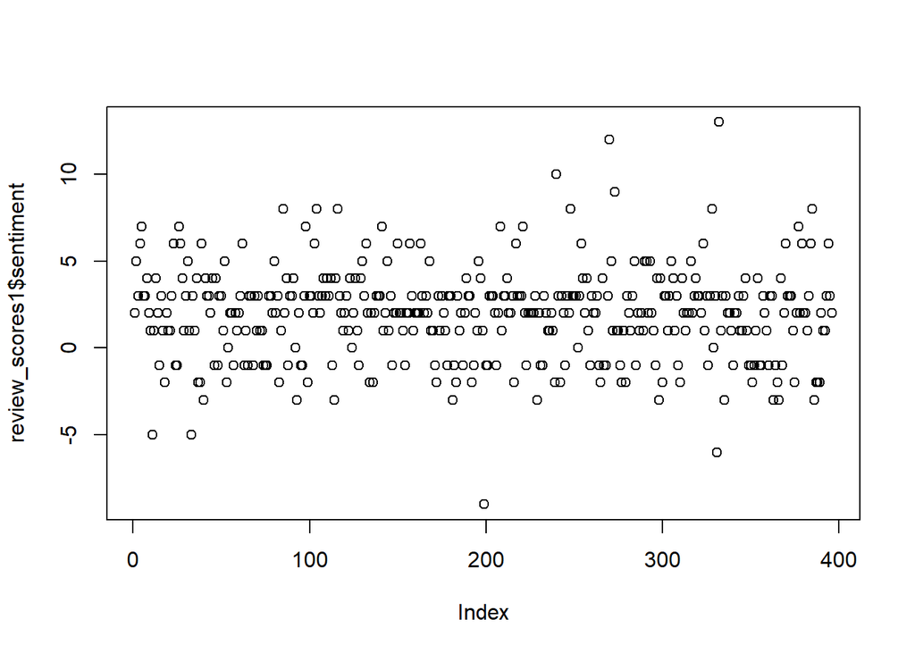

```r
plot(review_scores1$sentiment)
```

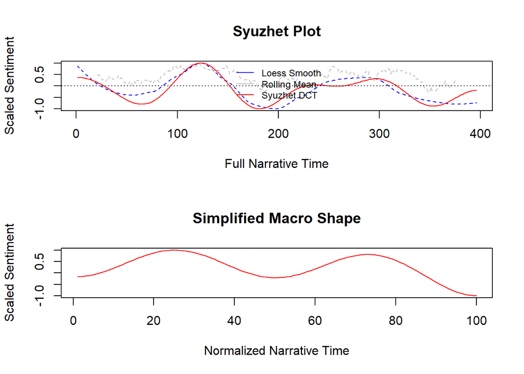

```r
simple_plot(review_scores1$sentiment)
```

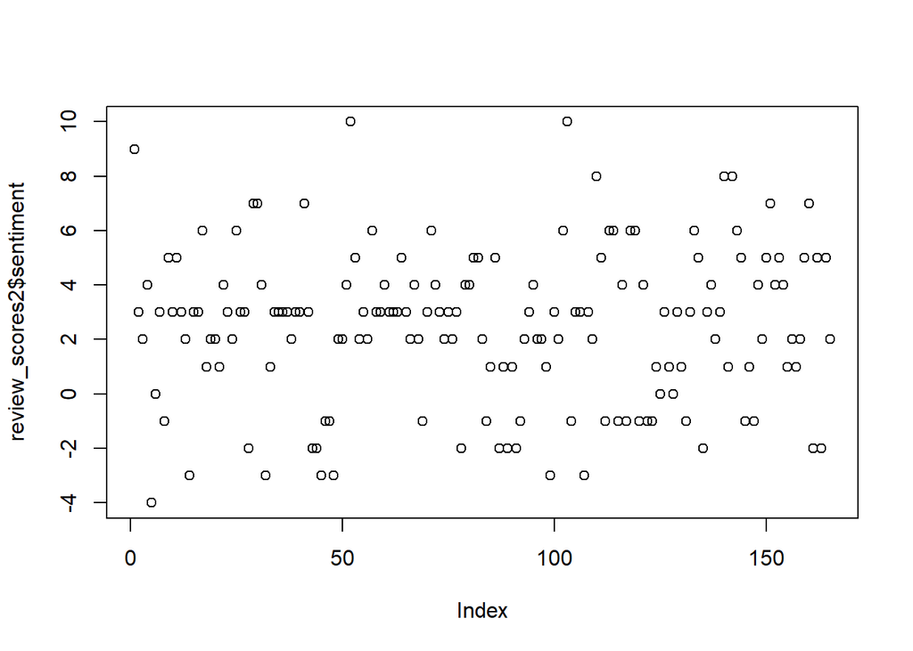

```r
plot(review_scores2$sentiment)
```

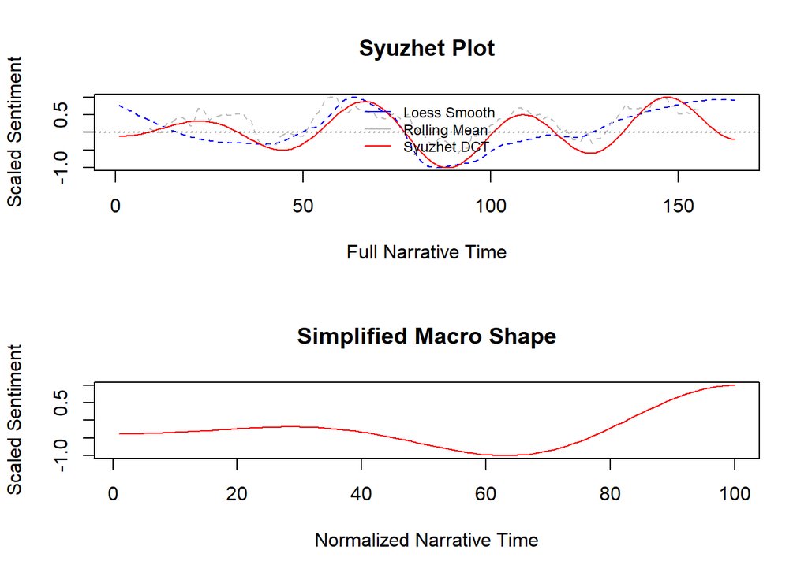

```r
simple_plot(review_scores2$sentiment)
```

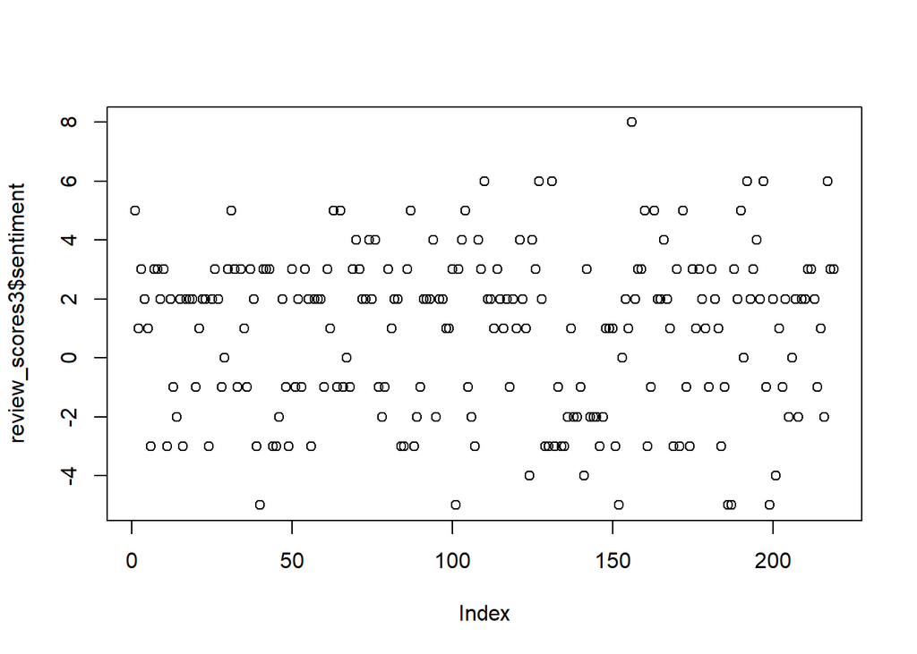

```r
plot(review_scores3$sentiment)
```

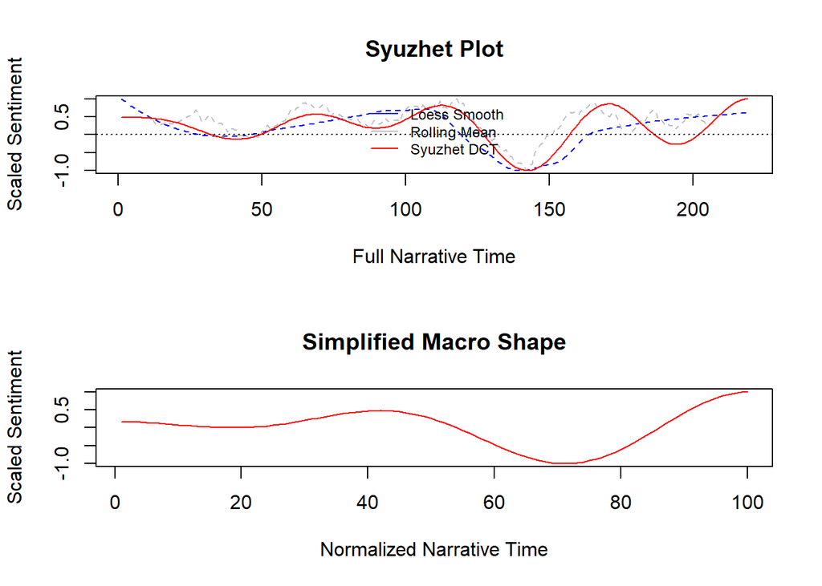

```r
simple_plot(review_scores3$sentiment)
```

## Results

Based on the sentiment scores, it seems the model does a pretty decent job of identifying whether the review is positive or negative. Based on the central tendency measures, and scatter plots, it appears the reviews are overall positive. Although the model does a good job, it seems it it could do better when there is more text to analyze in a review. Additionally, the model is also hindered slightly due to the fact a lot of the review lexicon is not included in the “AFINN” lexicon.

Below, the Discrete Cosine Similarity is conducted. For the managers of the hotels, the results of the DCT can be useful for identifying patterns in the overall emotional tone of a text

### Getting the Discrete Cosine Transform of the Text Data

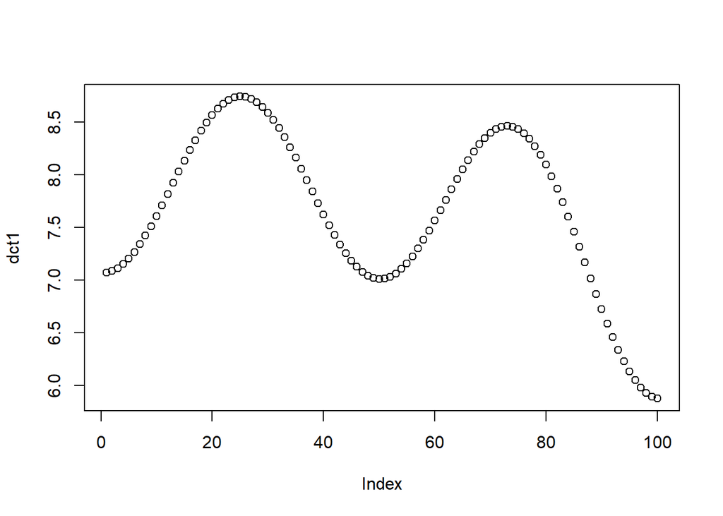

```r
dct1 <- get_dct_transform(review_scores1$sentiment)

dct2 <- get_dct_transform(review_scores2$sentiment)

dct3 <- get_dct_transform(review_scores3$sentiment)


plot(dct1)
```

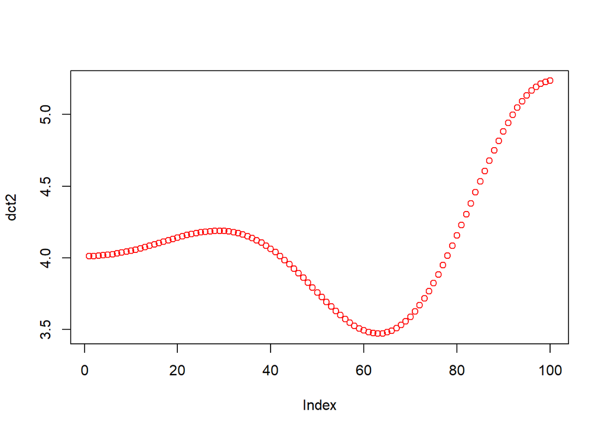

```r
plot(dct2, col = "red")
```

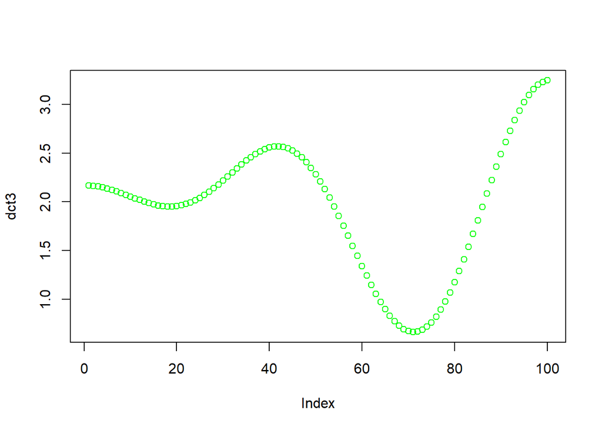

```r
plot(dct3, col = "green")
```

## Ethical Practices : Possible Abuses and Examples

Sentiment analysis, as used in this project, involves analyzing the emotional tone of text, such as whether a statement is positive, negative, or neutral. While sentiment analysis has many potential benefits, such as helping hotels gauge public opinion on their services, there are also several possible abuses that might occur due to sentiment analysis of text. Two possible abuses include discrimination and misrepresentation.

Discrimination: Sentiment analysis may be used to discriminate against individuals based on their race, ethnicity, gender, sexual orientation, or other characteristics. For example, a sentiment analysis tool might classify certain types of language as “negative” or “threatening” and be used to flag individuals for further scrutiny or exclusion.

Misrepresentation: Sentiment analysis may be used to misrepresent the true emotional tone of a message or text. For example, a political campaign might use sentiment analysis to spin negative feedback about their candidate into positive sentiment, or to discredit negative sentiment about their opponent. As can be seen in this project, some of the hotel reviews read as an overall poitive review but the sentiment score was negative. This is misrepresentative of the actual review.